# Introduction – Monastery novices network

Analysis of complex networks with algebra* Sunbelt 2022 Conference – Workshop 39 (part 1)

Antonio Rivero Ostoic

Sch Culture & Soc, Aarhus University

jaro@cas.au.dk

4 July 2022

## Plotting in R with `"multigraph"`

```r
# install packages from CRAN
install.packages("multiplex", "multigraph")

# or install packages from GitHub
devtools::install_github("mplex/multiplex")
devtools::install_github("mplex/multigraph")
```

## Monastery novices network

The monastery novices network is a directed, multiplex, signed, valued (and longitudinal) configuration.

```r
# load the "multiplex" package
library("multiplex")
```

```r
# read sampson monastery dataset as Ucinet DL file
samp <- read.dl("http://vlado.fmf.uni-lj.si/pub/networks/data/ucinet/sampson.dat")
```

```r
# what types of tie the network has?
dimnames(samp)[[3]]
```

```
 [1] "SAMPLK1" "SAMPLK2" "SAMPLK3" "SAMPDLK" "SAMPES"  "SAMPDES" "SAMPIN"  "SAMPNIN" "SAMPPR"  "SAMNPR"
```

These relations are “like T1-T3”, “dislike”, “esteem”, “disesteem”, “influence” (pos/neg), “praise” (pos/neg).

```r
# load the "multiplex" package
library("multigraph")
```

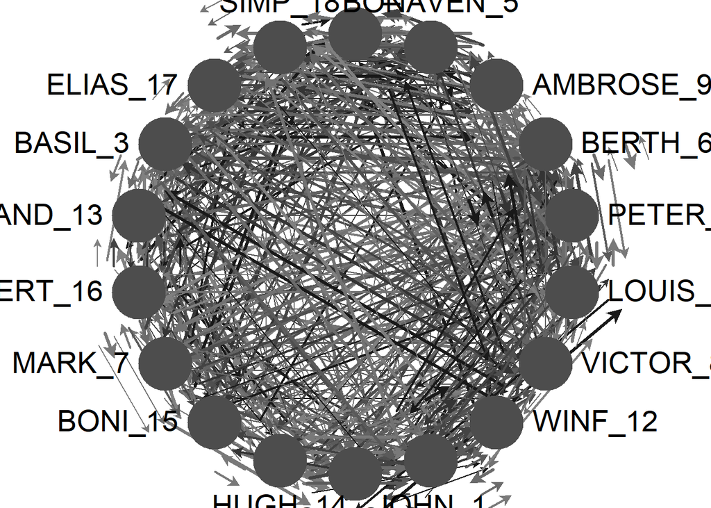

*Monastery novices network with circular default layout*

```r
# plot as valued multigraph
multigraph(samp, valued=TRUE)
```

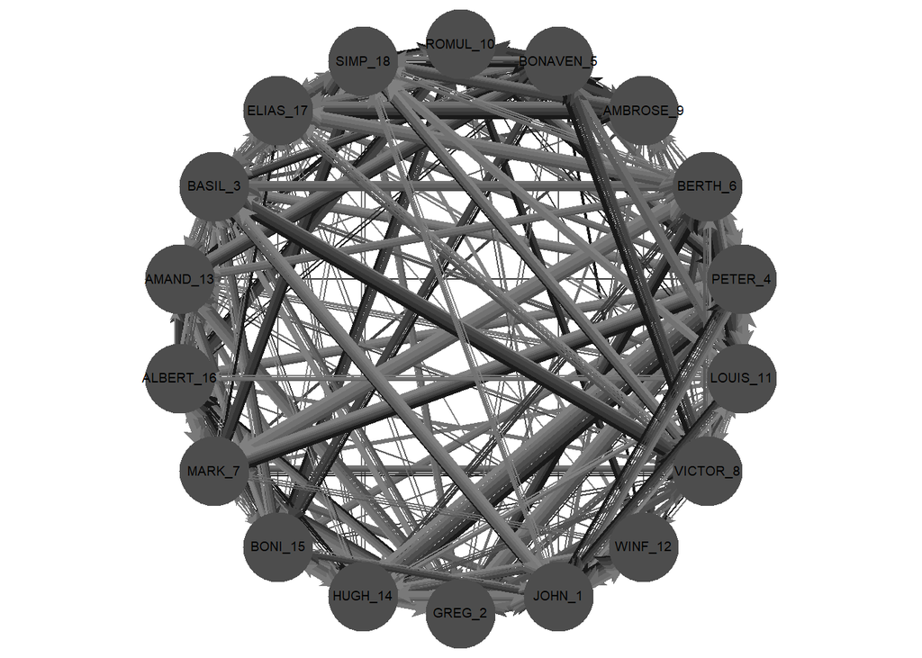

*Monastery novices network with customized values*

```r
# plot valued multigraph
multigraph(samp, valued=TRUE, bwd=.1, pos=0, fsize=6)
```

### Bundle patterns

```r
# enumeration of bundle class types
bundle.census(samp)
```

```
      BUNDLES NULL ASYMM RECIP T.ENTR T.EXCH MIXED FULL
TOTAL     134   19    20     1     37      8    68    0
```

```r
# bundle patterns in the monastery novices network
summaryBundles(bundles(samp))
```

```
                                                                           Bundles
Asym1                                             ->{SAMPLK1} (WINF_12, BONAVEN_5)
Asym2                                              ->{SAMPLK1} (BASIL_3, ROMUL_10)
...                                                                            ...
Asym20                                              ->{SAMNPR} (AMAND_13, SIMP_18)
Recp                                              <->{SAMPLK3} (BONI_15, VICTOR_8)
Tent1                     ->{SAMPDLK} ->{SAMPDES} ->{SAMNPR} (ALBERT_16, ELIAS_17)
Tent2          ->{SAMPDLK} ->{SAMPDES} ->{SAMPNIN} ->{SAMNPR} (ALBERT_16, PETER_4)
...                                                                            ...
```

### Relational system

Directed multiplex networks typically have differents relational systems inside. To look at these, recall network types of tie in the monastery novices network.

```r
# network's types of tie
dimnames(samp)[[3]]
```

```
 [1] "SAMPLK1" "SAMPLK2" "SAMPLK3" "SAMPDLK" "SAMPES"  "SAMPDES" "SAMPIN"  "SAMPNIN" "SAMPPR"  "SAMNPR"
```

These ties are “like T1-T3”, “dislike”, “esteem”, “disesteem”, “influence” (pos/neg), “praise” (pos/neg).

Extracting a system of strong bonds having positive ties is obtained with function `rel.sys()`.

```r
# choose positive ties in the network
sampsb <- rel.sys(samp[,,c(3,5,7,9)], type="toarray", bonds="strong")
```

The system of strong bonds has four types of relations among 17 actors and where `"Amand"`is disregarded.

```r
# network length dimensions
dim(sampsb)
```

```
[1] 17 17  4
```

### Graphs representation

We define a new scope to plot the graph of the monastery novices network.

```r
# scope to define node / edge / graph characteristics
R> scps <- list(fsize=8, pos=0, vcol="#AEAEAE", vcol0="#808080",
+    ecol="#808080", bwd=.4, rot=145, mirrorY=TRUE)
```

```r
scps <- list(fsize=8, pos=0, vcol="#AEAEAE", vcol0="#808080", ecol="#808080", bwd=.4, rot=145, mirrorY=TRUE)
```

And then we proceed with the plotting with a force-directed layout.

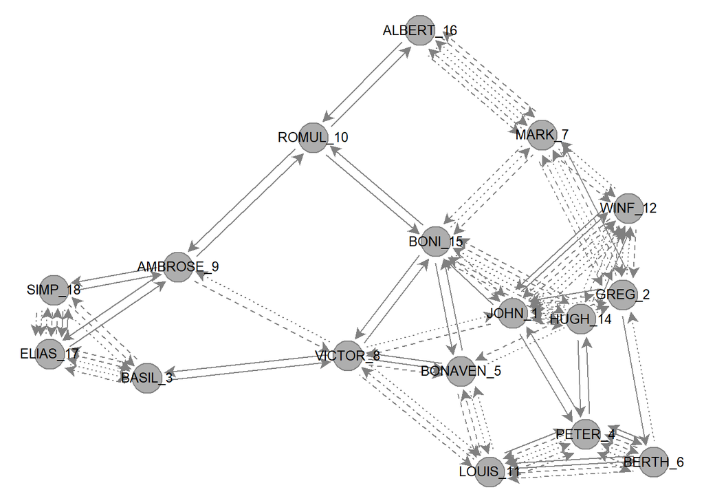

*System of strong bonds of monastery novices network*

```r
# plot graph with a reproducible force-directed layout
multigraph(sampsb, layout="force", seed=12, scope=scps)
```

### Graph with customized labels

It is possible with `"multigraph"` to customize node labels of the above graph.

```r
# vector with the monk names
R> monks <- c("Ramuald","Bonaventure","Ambrose","Berthold","Peter",
+          "Louis","Victor","Winfrid","JohnBosco","Gregory","Hugh",
+          "Boniface","Mark","Albert","Basil","Elias","Simplicius")
```

Then we use argument `lbs` in `"multigraph"`.

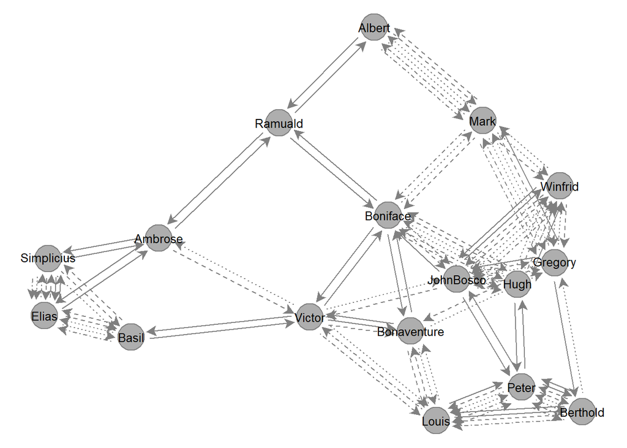

*Strong bonds in monastery novices with customized node labels*

```r
# plot graph with a reproducible force-directed layout
multigraph(sampsb, layout="force", seed=12, scope=scps, lbs=monks)
```

#### Note

Both `multiplex` and `multigraph` are available at CRAN.

##### Content

- Introduction – Monastery novices network
- Elementary Algebraic Structures
- Role Structure in Multiplex Networks
- Decomposition of Role Structures
- Signed Networks
- Affiliation Networks
- Multilevel Networks